# Análisis estadístico encuesta - Susalud 2015

Luis Curi

[figure not shown]

# 1 *Tratamiento de datos*

## 1.1 **Características generales**

```r
#Importación de la base de datos

base<-read_sav("http://portal.susalud.gob.pe/wp-content/uploads/archivo/base-de-datos/2015/CUESTIONARIO%2002%20-%20CAPITULOS.sav")
```

```r
#Cantidad de filas y columnas
dim(base)
```

```
## [1] 5067  270
```

La encuesta mostrada a continuación fue realizada a **5067 profesionales de la salud** en el año 2015 por la Superintendendia Nacional de Salud, la cual involucra médicos y enfermeras de ambos sexos. La información contenida en el dataset cuenta con **270 variables**, mostrando a continuacion una muestra de la base de datos:

```r
##Diez Primeras columnas y filas
base[1:10,1:10]
```

```
## # A tibble: 10 x 10
##       ID USUARIOID CCDD  DEPARTAMENTO CCPP  PROVIN~1 CCDI  DISTR~2 cccp  nombr~3
##    <dbl> <chr>     <chr> <chr>        <chr> <chr>    <chr> <chr>   <chr> <chr>
##  1     1 EVAL3     01    AMAZONAS     01    CHACHAP~ 01    CHACHA~ 0001  CHACHA~
##  2     1 EVAL3     01    AMAZONAS     01    CHACHAP~ 01    CHACHA~ 0001  CHACHA~
##  3     1 EVAL3     01    AMAZONAS     01    CHACHAP~ 01    CHACHA~ 0001  CHACHA~
##  4     1 EVAL3     01    AMAZONAS     01    CHACHAP~ 01    CHACHA~ 0001  CHACHA~
##  5     1 EVAL3     01    AMAZONAS     01    CHACHAP~ 01    CHACHA~ 0001  CHACHA~
##  6     1 EVAL3     01    AMAZONAS     01    CHACHAP~ 01    CHACHA~ 0001  CHACHA~
##  7     1 EVAL3     01    AMAZONAS     01    CHACHAP~ 01    CHACHA~ 0001  CHACHA~
##  8     1 EVAL3     01    AMAZONAS     01    CHACHAP~ 01    CHACHA~ 0001  CHACHA~
##  9     1 EVAL3     01    AMAZONAS     01    CHACHAP~ 01    CHACHA~ 0001  CHACHA~
## 10     1 EVAL3     01    AMAZONAS     01    CHACHAP~ 01    CHACHA~ 0001  CHACHA~
## # ... with abbreviated variable names 1: PROVINCIA, 2: DISTRITO, 3: nombreCP
```

## 1.2 **Selección de variables**

A continuación se muestra las variables relevantes para nuestro caso de estudio:

Estas son:

**Profesión** = C2P1, **Sexo** = C2P4, **Ingresos** = C2P28, **Edad** = C2P2EDAD, **Universidad de estudios** = C2P11, **Número de dependientes** = C2P9, **Tipo de contrato** = C2P7, **Realiza labor docente adicional** = C2P26, **Horas de trabajo por semana** = C2P27, **Nivel de satisfacción** = C2P29

```r
###Selección de variables de estudio
base1<-select(base,C2P1,C2P4,C2P28,C2P2EDAD,C2P11,C2P9,C2P7,C2P26,C2P27,C2P29)

##cambiar de nombre a las variables
base1 <-rename(base1,Profesión=C2P1,Sexo=C2P4,Ingresos=C2P28,Edad=C2P2EDAD,Universidad_de_estudios=C2P11,Número_de_dependientes=C2P9,Tipo_de_contrato=C2P7,Realiza_labor_docente_adicional=C2P26,Horas_de_trabajo_por_semana=C2P27,Nivel_de_satisfacción=C2P29)
summary(base1)
```

```
##    Profesión          Sexo         Ingresos          Edad
##  Min.   :1.000   Min.   :1.00   Min.   :1.000   Min.   :23.00
##  1st Qu.:1.000   1st Qu.:1.00   1st Qu.:3.000   1st Qu.:35.00
##  Median :2.000   Median :2.00   Median :4.000   Median :44.00
##  Mean   :1.562   Mean   :1.63   Mean   :4.195   Mean   :44.67
##  3rd Qu.:2.000   3rd Qu.:2.00   3rd Qu.:6.000   3rd Qu.:54.00
##  Max.   :2.000   Max.   :2.00   Max.   :7.000   Max.   :88.00
##
##  Universidad_de_estudios Número_de_dependientes Tipo_de_contrato
##  Min.   :1.000           Min.   : 0.000         Min.   :1.000
##  1st Qu.:4.000           1st Qu.: 1.000         1st Qu.:2.000
##  Median :8.000           Median : 2.000         Median :4.000
##  Mean   :6.153           Mean   : 2.288         Mean   :3.718
##  3rd Qu.:8.000           3rd Qu.: 3.000         3rd Qu.:5.000
##  Max.   :8.000           Max.   :14.000         Max.   :6.000
##                          NA's   :9
##  Realiza_labor_docente_adicional Horas_de_trabajo_por_semana
##  Min.   :1.00                    Min.   :  2.00
##  1st Qu.:2.00                    1st Qu.: 36.00
##  Median :2.00                    Median : 39.00
##  Mean   :1.81                    Mean   : 45.03
##  3rd Qu.:2.00                    3rd Qu.: 50.00
##  Max.   :2.00                    Max.   :130.00
##
##  Nivel_de_satisfacción
##  Min.   :1.0
##  1st Qu.:3.0
##  Median :4.0
##  Mean   :3.5
##  3rd Qu.:4.0
##  Max.   :5.0
##
```

Se observa un resúmen estadístico de las 10 variables seleccionadas, este resumen contempla promedios, mediana, cuartiles, minimos y maximos.

Tambien podemos observar la existencia de variables cualitativas expresadas de forma numérica, las cuales a continuación se identifican y convierten a su tipo original.

## 1.3 **Filtrado y conversión de datos**

Para el análisis solo se debe considerar la profesion médicos, por lo tanto la cantidad de filas o encuestas realizadas se reduce de 5067 a 2219, y la cantidad de variables de 270 a 10. Información con la cual se trabajará.

```r
##Filtrar datos solo con profesión médicos
base2<-subset(base1, Profesión == 1)

##El dataframe tiene 2219 filas y 10 columnas
dim(base2)
```

```
## [1] 2219   10
```

Ahora se realiza la conversión de datos cualitativos, ya que estos en su estado original se encuentran como numéricos

```r
##Convirtiendo las variables
base3<-base2
base3$Profesión<-factor(base3$Profesión,levels=c(1),labels=c("Médico"))
base3$Sexo<-factor(base3$Sexo,levels=c(1,2),labels=c("Hombre", "Mujer"))
base3$Ingresos<-factor(base3$Ingresos,levels=c(1,2,3,4,5,6,7),labels=c("Menor a s/. 1000", "DE s/. 1000 a s/. 2000", "DE s/. 2001 a s/. 3000", "DE s/. 3001 a s/. 4000", "DE s/. 4001 a s/. 5000", "Mas de s/. 5000", "NO RESPONDE"))
base3$Universidad_de_estudios<-factor(base3$Universidad_de_estudios,levels=c(1,2,3,4,5,6,7,8),labels=c("Univ.Nacional Mayor de San Marcos", "Univ. Nacional Federico Villarreal", "Univ. Nacional de Trujillo", "Univ. Nacional del Centro", "Univ.Nacional San Luis Gonzaga de Ica", "Univ. Particular Cayetano Heredia", "Univ. Particular San Martin de Porres", "Otro"))
base3$Tipo_de_contrato<-factor(base3$Tipo_de_contrato,levels=c(1,2,3,4,5,6),labels=c("Locaciòn de servicios (Honorarios profesionales)", "Contrato Administrativo de Servicios (CAS)", "Contrato a plazo fijo (sujeto a modalidad)", "Nombrado, permanente", "Plazo indeterminado o indefinido (D.S.728)", "Otro"))
base3$Realiza_labor_docente_adicional<-factor(base3$Realiza_labor_docente_adicional,levels=c(1,2),labels=c("Si", "No"))
base3$Nivel_de_satisfacción<-factor(base3$Nivel_de_satisfacción,levels=c(0,1,2,3,4,5,6),labels=c("NO SABE/NO RESPONDE", "Muy insatisfecho/a", "Insatisfecho/a", "Ni satisfecho/a  Ni insatisfecho/a", "Satisfecho/a", "Muy satisfecho/a","NO SABE/NO RESPONDE"))

summary(base3)
```

```
##   Profesión        Sexo                        Ingresos         Edad
##  Médico:2219   Hombre:1657   Menor a s/. 1000      :   1   Min.   :24.00
##                Mujer : 562   DE s/. 1000 a s/. 2000:  24   1st Qu.:37.00
##                              DE s/. 2001 a s/. 3000: 112   Median :46.00
##                              DE s/. 3001 a s/. 4000: 268   Mean   :46.45
##                              DE s/. 4001 a s/. 5000: 601   3rd Qu.:56.00
##                              Mas de s/. 5000       :1148   Max.   :88.00
##                              NO RESPONDE           :  65
##                           Universidad_de_estudios Número_de_dependientes
##  Otro                                 :946        Min.   : 0.000
##  Univ.Nacional Mayor de San Marcos    :421        1st Qu.: 1.000
##  Univ. Nacional de Trujillo           :233        Median : 2.000
##  Univ.Nacional San Luis Gonzaga de Ica:199        Mean   : 2.497
##  Univ. Nacional Federico Villarreal   :178        3rd Qu.: 3.000
##  Univ. Particular San Martin de Porres:107        Max.   :12.000
##  (Other)                              :135        NA's   :6
##                                          Tipo_de_contrato
##  Locaciòn de servicios (Honorarios profesionales):158
##  Contrato Administrativo de Servicios (CAS)      :279
##  Contrato a plazo fijo (sujeto a modalidad)      :138
##  Nombrado, permanente                            :881
##  Plazo indeterminado o indefinido (D.S.728)      :707
##  Otro                                            : 56
##
##  Realiza_labor_docente_adicional Horas_de_trabajo_por_semana
##  Si: 627                         Min.   :  2.00
##  No:1592                         1st Qu.: 38.00
##                                  Median : 48.00
##                                  Mean   : 51.07
##                                  3rd Qu.: 60.00
##                                  Max.   :130.00
##
##                         Nivel_de_satisfacción
##  NO SABE/NO RESPONDE               :   0
##  Muy insatisfecho/a                :  64
##  Insatisfecho/a                    : 343
##  Ni satisfecho/a  Ni insatisfecho/a: 439
##  Satisfecho/a                      :1261
##  Muy satisfecho/a                  : 112
##
```

Se observa un resúmen estadístico de las 10 variables seleccionadas, este resumen contempla promedios, mediana, cuartiles, minimos y maximos.

# 2 *Resolución de preguntas del caso*

## 2.1 **Identificar el tipo de variable**

### 2.1.1 Variables cualitativas

La variable sexo corresponde a una cualitativa dicotómica, Ingresos representa una cualitativa ordinal, universidad de estudios corresponde a cualitativa nominal, tipo de contrato tambien corresponde a una cualitativa nominal, Realiza labor docente adicional correspnde a una cualitativa dicotómica y nivel de satisfacción corresponde a cualitativa ordinal.

```r
cuali <- select(base3,Profesión, Sexo,Ingresos, Universidad_de_estudios, Tipo_de_contrato, Realiza_labor_docente_adicional,Nivel_de_satisfacción )##ingresos es una variable cuanti, pero veo que está expresado como cualitativa, de ser así. ¿no responde deberia considerarse como na o no deberia considerarse en el estudio? por que no corresponderia a ninguna escala ordinal.
summary(cuali)
```

```
##   Profesión        Sexo                        Ingresos
##  Médico:2219   Hombre:1657   Menor a s/. 1000      :   1
##                Mujer : 562   DE s/. 1000 a s/. 2000:  24
##                              DE s/. 2001 a s/. 3000: 112
##                              DE s/. 3001 a s/. 4000: 268
##                              DE s/. 4001 a s/. 5000: 601
##                              Mas de s/. 5000       :1148
##                              NO RESPONDE           :  65
##                           Universidad_de_estudios
##  Otro                                 :946
##  Univ.Nacional Mayor de San Marcos    :421
##  Univ. Nacional de Trujillo           :233
##  Univ.Nacional San Luis Gonzaga de Ica:199
##  Univ. Nacional Federico Villarreal   :178
##  Univ. Particular San Martin de Porres:107
##  (Other)                              :135
##                                          Tipo_de_contrato
##  Locaciòn de servicios (Honorarios profesionales):158
##  Contrato Administrativo de Servicios (CAS)      :279
##  Contrato a plazo fijo (sujeto a modalidad)      :138
##  Nombrado, permanente                            :881
##  Plazo indeterminado o indefinido (D.S.728)      :707
##  Otro                                            : 56
##
##  Realiza_labor_docente_adicional                        Nivel_de_satisfacción
##  Si: 627                         NO SABE/NO RESPONDE               :   0
##  No:1592                         Muy insatisfecho/a                :  64
##                                  Insatisfecho/a                    : 343
##                                  Ni satisfecho/a  Ni insatisfecho/a: 439
##                                  Satisfecho/a                      :1261
##                                  Muy satisfecho/a                  : 112
##
```

### 2.1.2 Variables cuantitativas

La variable edad corresponde a cuantitativa discreta, número de dependientes es una variable cuantitativa discreta, horas de trabajo por semana corresponde a cuantitativa discreta.

```r
cuanti <- select(base3, Edad,Número_de_dependientes,Horas_de_trabajo_por_semana )
summary(cuanti)
```

```
##       Edad       Número_de_dependientes Horas_de_trabajo_por_semana
##  Min.   :24.00   Min.   : 0.000         Min.   :  2.00
##  1st Qu.:37.00   1st Qu.: 1.000         1st Qu.: 38.00
##  Median :46.00   Median : 2.000         Median : 48.00
##  Mean   :46.45   Mean   : 2.497         Mean   : 51.07
##  3rd Qu.:56.00   3rd Qu.: 3.000         3rd Qu.: 60.00
##  Max.   :88.00   Max.   :12.000         Max.   :130.00
##                  NA's   :6
```

## 2.2 **Tabla de frecuencias y gráfico: Variable cualitativa**

### 2.2.1 variable sexo

```r
freq(base3$Sexo)
```

```
## Frequencies
## base3$Sexo
## Type: Factor
##
##                Freq   % Valid   % Valid Cum.   % Total   % Total Cum.
## ------------ ------ --------- -------------- --------- --------------
##       Hombre   1657     74.67          74.67     74.67          74.67
##        Mujer    562     25.33         100.00     25.33         100.00
##         <NA>      0                               0.00         100.00
##        Total   2219    100.00         100.00    100.00         100.00
```

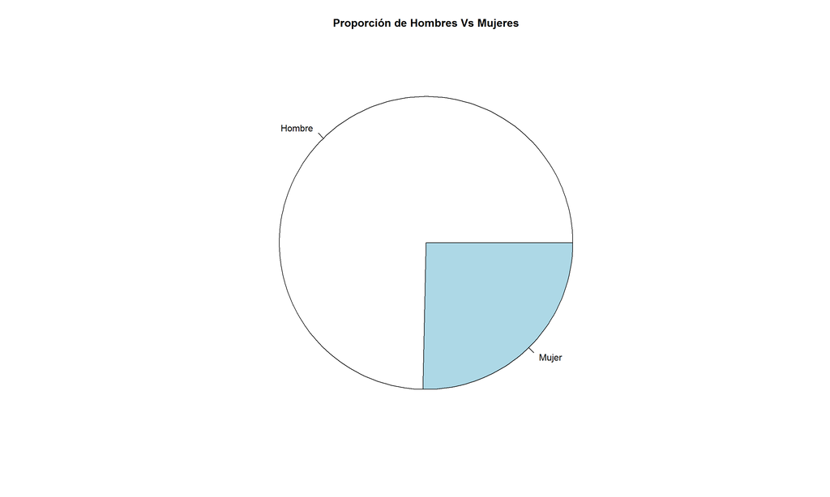

```r
varsexo<-table(base3$Sexo)
pie(varsexo,
    main="Proporción de Hombres Vs Mujeres")
```

### 2.2.2 variable Ingresos

```r
freq(base3$Ingresos)
```

```
## Frequencies
## base3$Ingresos
## Type: Factor
##
##                                Freq   % Valid   % Valid Cum.   % Total   % Total Cum.
## ---------------------------- ------ --------- -------------- --------- --------------
##             Menor a s/. 1000      1     0.045          0.045     0.045          0.045
##       DE s/. 1000 a s/. 2000     24     1.082          1.127     1.082          1.127
##       DE s/. 2001 a s/. 3000    112     5.047          6.174     5.047          6.174
##       DE s/. 3001 a s/. 4000    268    12.078         18.251    12.078         18.251
##       DE s/. 4001 a s/. 5000    601    27.084         45.336    27.084         45.336
##              Mas de s/. 5000   1148    51.735         97.071    51.735         97.071
##                  NO RESPONDE     65     2.929        100.000     2.929        100.000
##                         <NA>      0                              0.000        100.000
##                        Total   2219   100.000        100.000   100.000        100.000
```

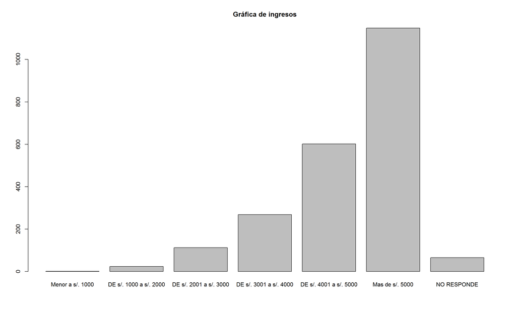

```r
plot(base3$Ingresos,main="Gráfica de ingresos")
```

### 2.2.3 variable Universidad de estudios

```r
freq(base3$Universidad_de_estudios)
```

```
## Frequencies
## base3$Universidad_de_estudios
## Type: Factor
##
##                                               Freq   % Valid   % Valid Cum.   % Total   % Total Cum.
## ------------------------------------------- ------ --------- -------------- --------- --------------
##           Univ.Nacional Mayor de San Marcos    421     18.97          18.97     18.97          18.97
##          Univ. Nacional Federico Villarreal    178      8.02          26.99      8.02          26.99
##                  Univ. Nacional de Trujillo    233     10.50          37.49     10.50          37.49
##                   Univ. Nacional del Centro     42      1.89          39.39      1.89          39.39
##       Univ.Nacional San Luis Gonzaga de Ica    199      8.97          48.36      8.97          48.36
##           Univ. Particular Cayetano Heredia     93      4.19          52.55      4.19          52.55
##       Univ. Particular San Martin de Porres    107      4.82          57.37      4.82          57.37
##                                        Otro    946     42.63         100.00     42.63         100.00
##                                        <NA>      0                               0.00         100.00
##                                       Total   2219    100.00         100.00    100.00         100.00
```

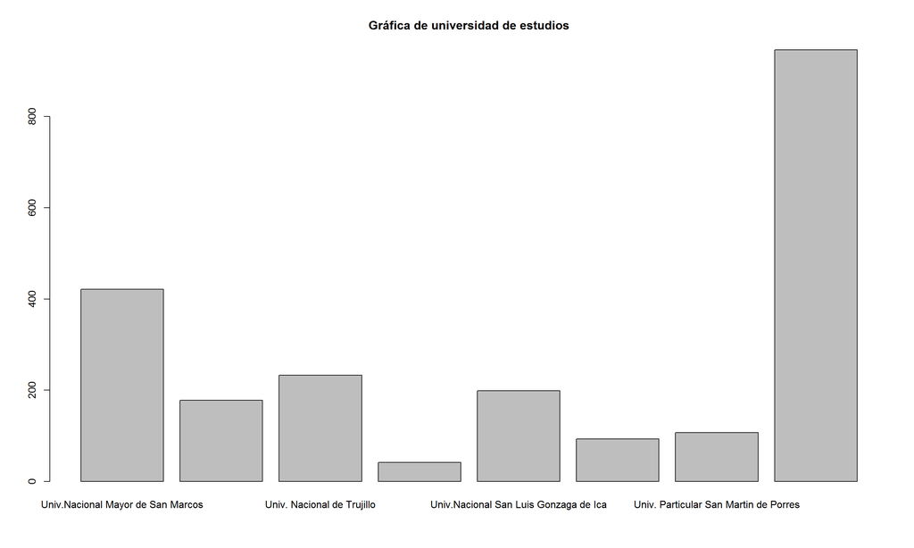

```r
plot(base3$Universidad_de_estudios,main="Gráfica de universidad de estudios")
```

### 2.2.4 variable Tipo de contrato

```r
freq(base3$Tipo_de_contrato)
```

```
## Frequencies
## base3$Tipo_de_contrato
## Type: Factor
##
##                                                          Freq   % Valid   % Valid Cum.   % Total   % Total Cum.
## ------------------------------------------------------ ------ --------- -------------- --------- --------------
##       Locaciòn de servicios (Honorarios profesionales)    158      7.12           7.12      7.12           7.12
##             Contrato Administrativo de Servicios (CAS)    279     12.57          19.69     12.57          19.69
##             Contrato a plazo fijo (sujeto a modalidad)    138      6.22          25.91      6.22          25.91
##                                   Nombrado, permanente    881     39.70          65.62     39.70          65.62
##             Plazo indeterminado o indefinido (D.S.728)    707     31.86          97.48     31.86          97.48
##                                                   Otro     56      2.52         100.00      2.52         100.00
##                                                   <NA>      0                               0.00         100.00
##                                                  Total   2219    100.00         100.00    100.00         100.00
```

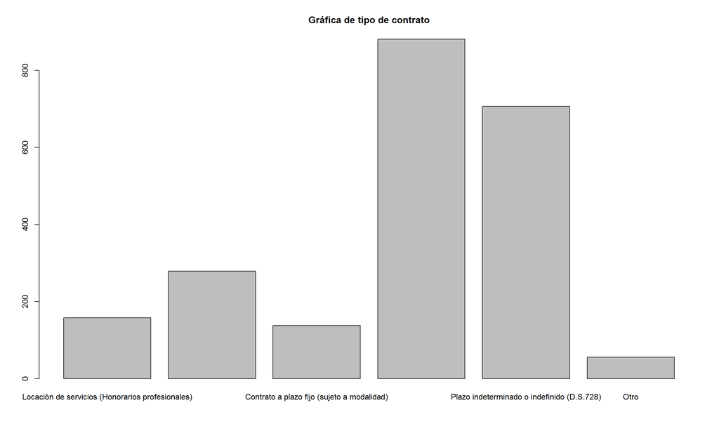

```r
plot(base3$Tipo_de_contrato ,main="Gráfica de tipo de contrato")
```

### 2.2.5 variable Realiza labor docente adicional

```r
freq(base3$Realiza_labor_docente_adicional)
```

```
## Frequencies
## base3$Realiza_labor_docente_adicional
## Type: Factor
##
##               Freq   % Valid   % Valid Cum.   % Total   % Total Cum.
## ----------- ------ --------- -------------- --------- --------------
##          Si    627     28.26          28.26     28.26          28.26
##          No   1592     71.74         100.00     71.74         100.00
##        <NA>      0                               0.00         100.00
##       Total   2219    100.00         100.00    100.00         100.00
```

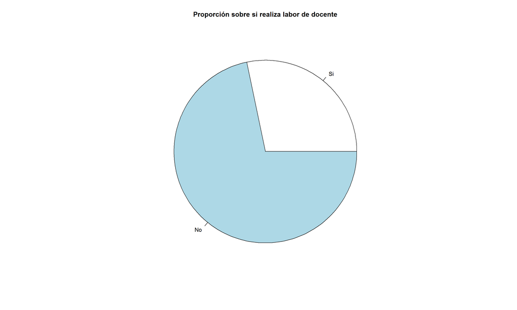

```r
varadicional<-table(base3$Realiza_labor_docente_adicional)
pie(varadicional,
    main="Proporción sobre si realiza labor de docente")
```

### 2.2.6 variable Nivel de satisfacción

```r
freq(base3$Nivel_de_satisfacción)
```

```
## Frequencies
## base3$Nivel_de_satisfacción
## Type: Factor
##
##                                            Freq   % Valid   % Valid Cum.   % Total   % Total Cum.
## ---------------------------------------- ------ --------- -------------- --------- --------------
##                      NO SABE/NO RESPONDE      0      0.00           0.00      0.00           0.00
##                       Muy insatisfecho/a     64      2.88           2.88      2.88           2.88
##                           Insatisfecho/a    343     15.46          18.34     15.46          18.34
##       Ni satisfecho/a  Ni insatisfecho/a    439     19.78          38.13     19.78          38.13
##                             Satisfecho/a   1261     56.83          94.95     56.83          94.95
##                         Muy satisfecho/a    112      5.05         100.00      5.05         100.00
##                                     <NA>      0                               0.00         100.00
##                                    Total   2219    100.00         100.00    100.00         100.00
```

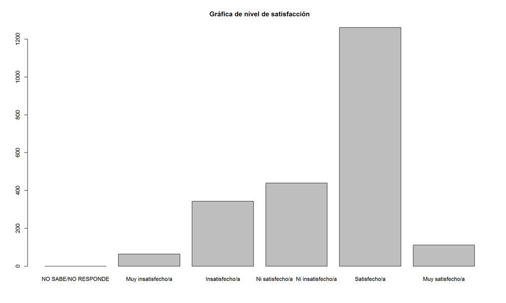

```r
plot(base3$Nivel_de_satisfacción,main="Gráfica de nivel de satisfacción")
```

## 2.3 **Tabla de frecuencias: Variable cuantitativa**

### 2.3.1 variable Edad

```r
Freq(base3$Edad, breaks=nclass.Sturges(base3$Edad))
```

```
##           level  freq   perc  cumfreq  cumperc
## 1   [23.9,28.9]    84   3.8%       84     3.8%
## 2   (28.9,33.8]   258  11.6%      342    15.4%
## 3   (33.8,38.8]   331  14.9%      673    30.3%
## 4   (38.8,43.7]   293  13.2%      966    43.5%
## 5   (43.7,48.6]   289  13.0%    1'255    56.6%
## 6   (48.6,53.5]   262  11.8%    1'517    68.4%
## 7   (53.5,58.5]   300  13.5%    1'817    81.9%
## 8   (58.5,63.4]   266  12.0%    2'083    93.9%
## 9   (63.4,68.3]   113   5.1%    2'196    99.0%
## 10  (68.3,73.2]    14   0.6%    2'210    99.6%
## 11  (73.2,78.2]     4   0.2%    2'214    99.8%
## 12  (78.2,83.1]     3   0.1%    2'217    99.9%
## 13  (83.1,88.1]     2   0.1%    2'219   100.0%
```

### 2.3.2 variable Número de dependientes

```r
Freq(base3$Número_de_dependientes, breaks=nclass.Sturges(base3$Número_de_dependientes))
```

```
##              level  freq   perc  cumfreq  cumperc
## 1   [-0.012,0.923]   260  11.7%      260    11.7%
## 2     (0.923,1.85]   336  15.2%      596    26.9%
## 3      (1.85,2.77]   557  25.2%    1'153    52.1%
## 4      (2.77,3.69]   537  24.3%    1'690    76.4%
## 5      (3.69,4.62]   304  13.7%    1'994    90.1%
## 6      (4.62,5.54]   132   6.0%    2'126    96.1%
## 7      (5.54,6.46]    56   2.5%    2'182    98.6%
## 8      (6.46,7.38]     9   0.4%    2'191    99.0%
## 9      (7.38,8.31]    16   0.7%    2'207    99.7%
## 10     (8.31,9.23]     1   0.0%    2'208    99.8%
## 11     (9.23,10.2]     4   0.2%    2'212   100.0%
## 12     (10.2,11.1]     0   0.0%    2'212   100.0%
## 13       (11.1,12]     1   0.0%    2'213   100.0%
```

### 2.3.3 variable Horas de trabajo por semana

```r
Freq(base3$Horas_de_trabajo_por_semana, breaks=nclass.Sturges(base3$Horas_de_trabajo_por_semana))
```

```
##           level  freq   perc  cumfreq  cumperc
## 1   [1.87,11.8]     6   0.3%        6     0.3%
## 2   (11.8,21.7]     9   0.4%       15     0.7%
## 3   (21.7,31.5]    11   0.5%       26     1.2%
## 4   (31.5,41.4]   751  33.8%      777    35.0%
## 5   (41.4,51.2]   534  24.1%    1'311    59.1%
## 6   (51.2,61.1]   517  23.3%    1'828    82.4%
## 7   (61.1,70.9]   141   6.4%    1'969    88.7%
## 8   (70.9,80.8]   168   7.6%    2'137    96.3%
## 9   (80.8,90.6]    50   2.3%    2'187    98.6%
## 10   (90.6,100]    20   0.9%    2'207    99.5%
## 11    (100,110]     1   0.0%    2'208    99.5%
## 12    (110,120]     7   0.3%    2'215    99.8%
## 13    (120,130]     4   0.2%    2'219   100.0%
```

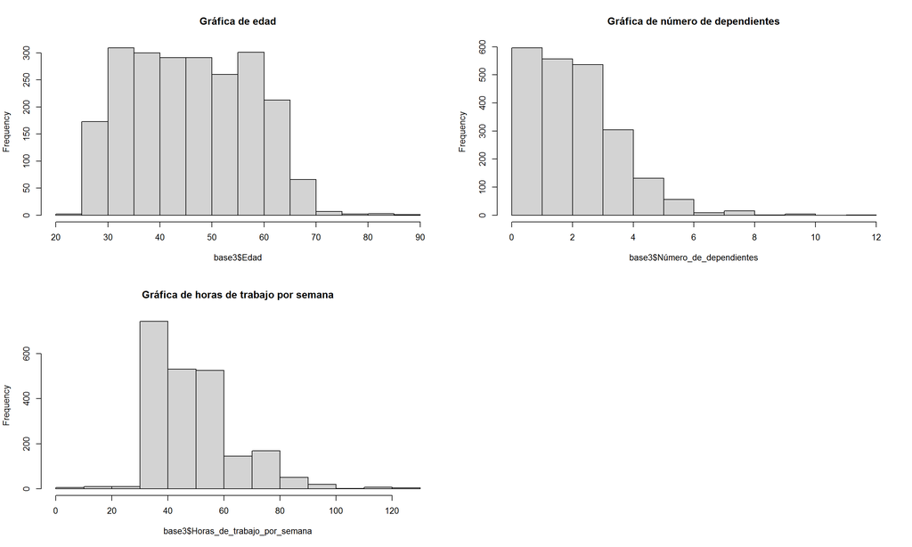

```r
par(mfrow = c(2,2))
hist(base3$Edad,main="Gráfica de edad")
hist(base3$Número_de_dependientes,main="Gráfica de número de dependientes")
hist(base3$Horas_de_trabajo_por_semana,main="Gráfica de horas de trabajo por semana")
```

## 2.4 **Asimetría de variables cuantitativas**

### 2.4.1 Histogramas

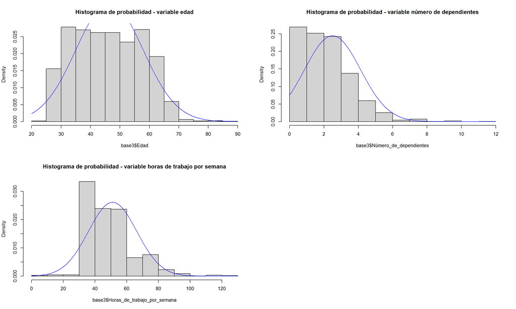

```r
par(mfrow = c(2,2))
hist(base3$Edad, probability = T ,main="Histograma de probabilidad - variable edad")
curve(dnorm(x, mean=46.44795, sd=11.38578),add=T,col="blue")
hist(base3$Número_de_dependientes , probability = T, main="Histograma de probabilidad - variable número de dependientes")
curve(dnorm(x, mean=2.496611,sd=1.629468),add=T,col="blue")
hist(base3$Horas_de_trabajo_por_semana, probability = T,main="Histograma de probabilidad - variable horas de trabajo por semana")
curve(dnorm(x, mean=51.06895, sd=15.24037),add=T,col="blue")
```

### 2.4.2 Coeficiente de asimetría de Fisher

```r
Fisher.asi   = function(x) mean((x - mean(x,na.rm = T))^3,na.rm = T)/sd(x,na.rm = T)^3
Fisher.asi(base3$Edad)
```

```
## [1] 0.143489
```

coeficiente de asimetría para la variable Edad

```r
Fisher.asi   = function(x) mean((x - mean(x,na.rm = T))^3,na.rm = T)/sd(x,na.rm = T)^3
Fisher.asi(na.omit(base3$Número_de_dependientes))
```

```
## [1] 0.6947413
```

coeficiente de asimetría para la variable Número de dependientes

```r
Fisher.asi   = function(x) mean((x - mean(x,na.rm = T))^3,na.rm = T)/sd(x,na.rm = T)^3
Fisher.asi(base3$Horas_de_trabajo_por_semana)
```

```
## [1] 1.064314
```

coeficiente de asimetría para la variable Horas de trabajo por semana

## 2.5 **Análisis de posición de variable: Horas de trabajo a la semana**

### 2.5.1 Gráficos

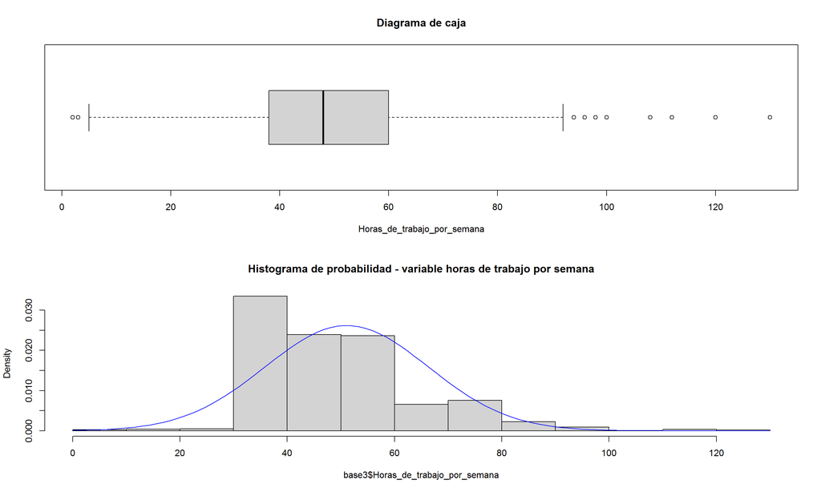

```r
par(mfrow = c(2,1))

box1<-boxplot(base3$Horas_de_trabajo_por_semana, xlab="Horas_de_trabajo_por_semana",main="Diagrama de caja", horizontal = T)
hist(base3$Horas_de_trabajo_por_semana, probability = T, main="Histograma de probabilidad - variable horas de trabajo por semana")
curve(dnorm(x, mean=51.06895, sd=15.24037),add=T,col="blue")
```

```r
outmin<-base3[base3$Horas_de_trabajo_por_semana <5 ,]
head(outmin$Horas_de_trabajo_por_semana)
```

```
## [1] 3 2
```

```r
mean(outmin$Horas_de_trabajo_por_semana)
```

```
## [1] 2.5
```

Se muestra los extremos minimos de la variable horas de trabajo por semana, así como el promedio de estos valores extremos

```r
outmax<-base3[base3$Horas_de_trabajo_por_semana >92 ,]
head(outmax$Horas_de_trabajo_por_semana)
```

```
## [1] 130 130 112 100 100 100
```

```r
mean(outmax$Horas_de_trabajo_por_semana)
```

```
## [1] 107.2
```

Se muestra los extremos maximos de la variable horas de trabajo por semana, así como el promedio de estos valores extremos

## 2.6 **Evaluación de normalidad de variables**

### 2.6.1 Variable Edad

Histograma

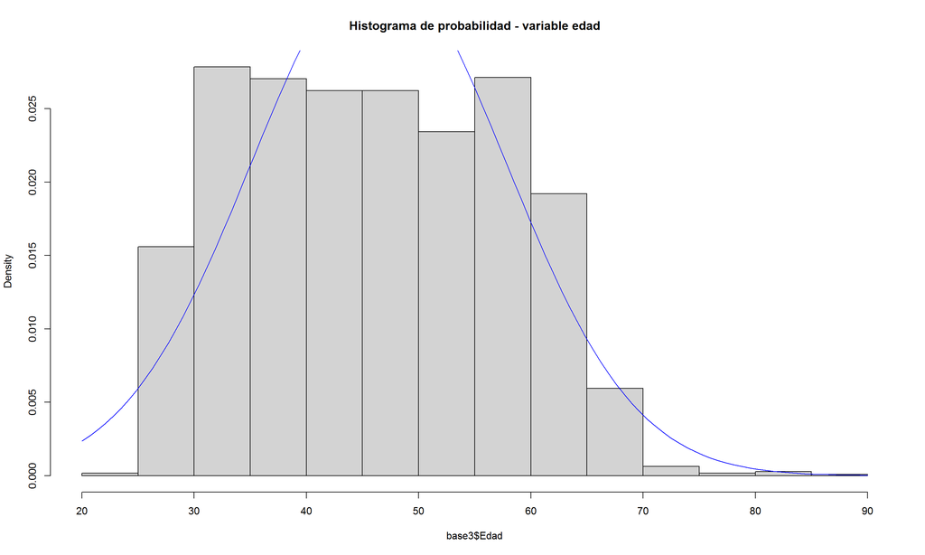

```r
hist(base3$Edad, probability = T, main="Histograma de probabilidad - variable edad")
curve(dnorm(x, mean=46.44795,sd=11.38578),add=T,col="blue")
```

Comparación de deciles

```r
deciles<-(0:10)/10

Empiricoedad<-quantile(base3$Edad, deciles)
Teoricoedad<-qnorm(deciles, mean=46.44795, sd=11.38578)
rbind(Empiricoedad, Teoricoedad)
```

```
##                0%      10%      20%      30%     40%      50%     60%      70%
## Empiricoedad   24 31.00000 35.00000 38.00000 42.0000 46.00000 50.0000 54.00000
## Teoricoedad  -Inf 31.85649 36.86544 40.47724 43.5634 46.44795 49.3325 52.41866
##                   80%      90% 100%
## Empiricoedad 58.00000 62.00000   88
## Teoricoedad  56.03046 61.03941  Inf
```

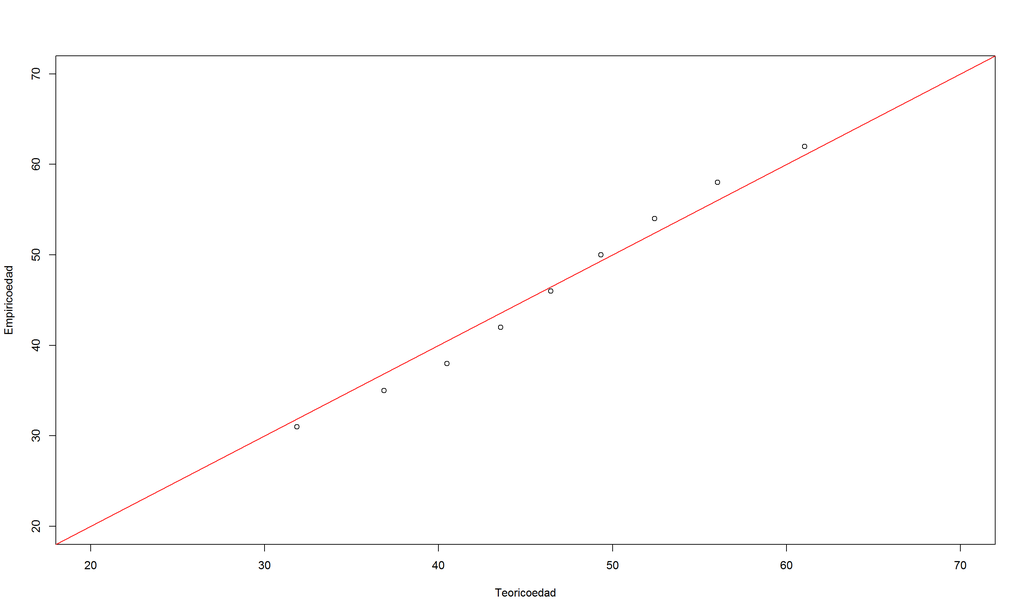

```r
plot(Teoricoedad, Empiricoedad, ylim=c(20,70), xlim=c(20,70))
abline(0,1, col="red")
```

Test de normalidad

```r
shapiro.test(base3$Edad)
```

```
##
##  Shapiro-Wilk normality test
##
## data:  base3$Edad
## W = 0.97007, p-value < 2.2e-16
```

```r
ks.test(base3$Edad, "pnorm", mean = mean(base3$Edad), sd = sd(base3$Edad))
```

```
##
##  Asymptotic one-sample Kolmogorov-Smirnov test
##
## data:  base3$Edad
## D = 0.074238, p-value = 4.771e-11
## alternative hypothesis: two-sided
```

Se aplica el test de shapiro para evaluar normalidad obteniendo así un p value menor a 0.05, rechazando la hipotesis nula que por defecto asumía normalidad en la variable edad. Por lo tanto se acepta la hipotesis alterna la cual indica que **los datos de la variable edad no sigue un comportamiento normal**, así mismo se puede observar esta conclusión en los graficos de comparación de deciles e histograma.

### 2.6.2 Variable horas de trabajo por semana

Histograma

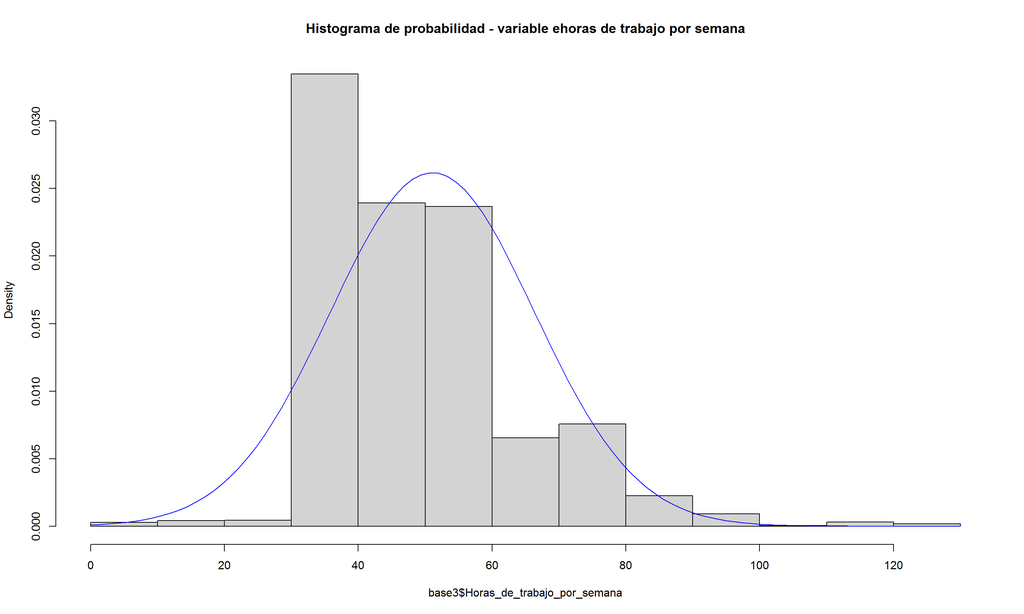

```r
hist(base3$Horas_de_trabajo_por_semana, probability = T, main="Histograma de probabilidad - variable ehoras de trabajo por semana")
curve(dnorm(x, mean=51.06895,sd=15.24037),add=T,col="blue")
```

Comparación de deciles

```r
Empiricohoras<-quantile( base3$Horas_de_trabajo_por_semana, deciles)
Teoricohoras<-qnorm(deciles, mean=51.06895, sd=15.24037)
rbind(Empiricohoras, Teoricohoras)
```

```
##                 0%      10%      20%      30%      40%      50%      60%
## Empiricohoras    2 36.00000 36.00000 40.00000 45.00000 48.00000 52.00000
## Teoricohoras  -Inf 31.53763 38.24233 43.07689 47.20785 51.06895 54.93005
##                    70%      80%      90% 100%
## Empiricohoras 60.00000 60.00000 72.00000  130
## Teoricohoras  59.06101 63.89557 70.60027  Inf
```

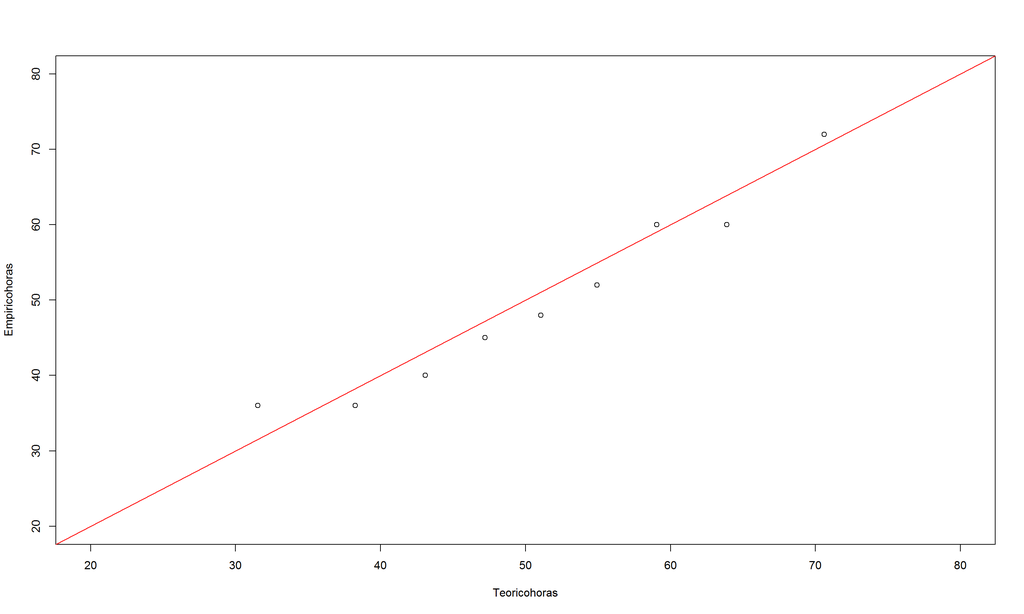

```r
plot(Teoricohoras, Empiricohoras, ylim=c(20,80), xlim=c(20,80))
abline(0,1, col="red")
```

Test de normalidad

```r
shapiro.test(base3$Horas_de_trabajo_por_semana)
```

```
##
##  Shapiro-Wilk normality test
##
## data:  base3$Horas_de_trabajo_por_semana
## W = 0.90947, p-value < 2.2e-16
```

```r
ks.test(base3$Horas_de_trabajo_por_semana, "pnorm", mean = mean(base3$Horas_de_trabajo_por_semana), sd = sd(base3$Horas_de_trabajo_por_semana))
```

```
##
##  Asymptotic one-sample Kolmogorov-Smirnov test
##
## data:  base3$Horas_de_trabajo_por_semana
## D = 0.13841, p-value < 2.2e-16
## alternative hypothesis: two-sided
```

Se aplica el test de shapiro para evaluar normalidad obteniendo así un p value menor a 0.05, rechazando la hipotesis nula que por defecto asumía normalidad en la variable horas de trabajo por semana. Por lo tanto se acepta la hipotesis alterna la cual indica que **los datos de la variable horas de trabajo por semana no sigue un comportamiento normal**, así mismo se puede observar esta conclusión en los graficos de comparación de deciles e histograma.

## 2.7 **Cálculo de Intervalos de confianza**

### 2.7.1 horas trabajadas por semana para mujeres

```r
z<- 1.96
basehtmujer<-subset(base3,Sexo == "Mujer")
mediahtmujer<-mean(basehtmujer$Horas_de_trabajo_por_semana)
nmujer<- length(basehtmujer$Horas_de_trabajo_por_semana)
desvmujer<-sd(basehtmujer$Horas_de_trabajo_por_semana)
errorstmujer<- desvmujer/sqrt(nmujer)
lim_infmujer<-mediahtmujer-(z*errorstmujer)
lim_supmujer<-mediahtmujer+(z*errorstmujer)
intervalo_mujer<-data.frame(nmujer, mediahtmujer, desvmujer, errorstmujer, lim_infmujer, lim_supmujer)
intervalo_mujer
```

```
##   nmujer mediahtmujer desvmujer errorstmujer lim_infmujer lim_supmujer
## 1    562     47.63523  14.35706     0.605616     46.44822     48.82224
```

### 2.7.2 horas trabajadas por semana para hombres

```r
z<- 1.96
basehthombre<-subset(base3,Sexo == "Hombre")
mediahthombre<-mean(basehthombre$Horas_de_trabajo_por_semana)
nhombre<- length(basehthombre$Horas_de_trabajo_por_semana)
desvhombre<-sd(basehthombre$Horas_de_trabajo_por_semana)
errorsthombre<- desvmujer/sqrt(nhombre)
lim_infhombre<-mediahthombre-(z*errorsthombre)
lim_suphombre<-mediahthombre+(z*errorsthombre)
intervalo_hombre<-data.frame(nhombre,mediahthombre,desvhombre, errorsthombre, lim_infhombre, lim_suphombre )
intervalo_hombre
```

```
##   nhombre mediahthombre desvhombre errorsthombre lim_infhombre lim_suphombre
## 1    1657      52.23355   15.35928      0.352699      51.54226      52.92484
```

### 2.7.3 Gráfico de intervalos de confianza

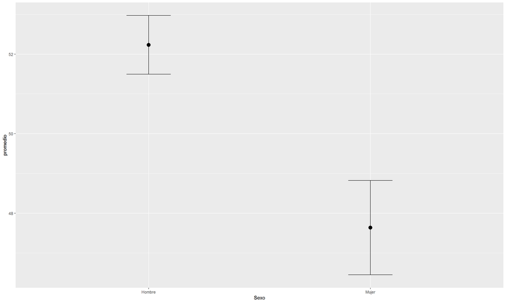

```r
##graficos
base3_hdtps<-base3 %>%
            group_by(Sexo) %>%
            summarise(mean_hdtps = mean(Horas_de_trabajo_por_semana), sd_hdtps= sd(Horas_de_trabajo_por_semana), num =length(Horas_de_trabajo_por_semana)) %>%
            mutate(len=1.96*sd_hdtps/sqrt(num))

graficos <- ggplot(data= base3_hdtps, mapping = aes(x=Sexo, y=mean_hdtps,
            ymin = mean_hdtps - len ,  ymax = mean_hdtps +len) )

graficos<-graficos + geom_point(size=3.5) +
    geom_errorbar(width = 0.2) +
    labs(tittle="95% confidence interbal", y= "promedio")
graficos
```

Según el cálculo de intervalos de confianza con un nivel de confianza del 95%, se concluye que si hay diferencia entre hombres y mujeres respecto a la variable horas de trabajo por semana, lo cual indica que los doctores hombres tiene más horas de trabajo por semana que las mujeres.

## 2.8 **Prueba de hipotesis, variable: número de dependientes**

A continuación se busca probar si el número de dependientes por médico sigue siendo en promedio = 2, para ello se realiza una prueba de hipótesis de la variable **Número de dependientes** siendo:

H0 = 2 H1 ≠ 2

### 2.8.1 Histograma

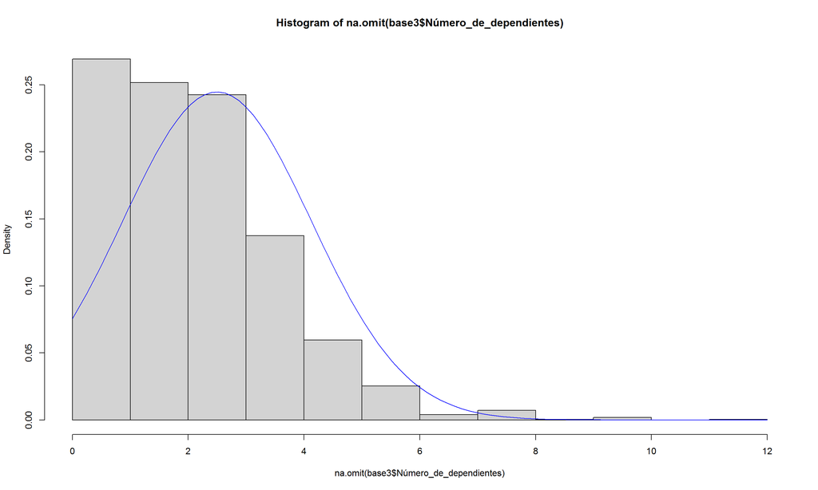

```r
hist(na.omit(base3$Número_de_dependientes), probability = T)
curve(dnorm(x, mean=2.496611,sd=1.629468),add=T,col="blue")
```

### Comparación de deciles

```r
Empiriconumdep<-quantile(na.omit(base3$Número_de_dependientes), probs=c(0,0.1,0.20,0.30,0.40, 0.5,0.60,0.70,0.8,0.90,1))
Teoriconumdep<-qnorm(deciles, mean=2.496611, sd=1.629468)
rbind(Empiriconumdep, Teoriconumdep )
```

```
##                  0%       10%      20%      30%     40%      50%      60%
## Empiriconumdep    0 0.0000000 1.000000 2.000000 2.00000 2.000000 3.000000
## Teoriconumdep  -Inf 0.4083637 1.125216 1.642117 2.08379 2.496611 2.909432
##                     70%      80%      90% 100%
## Empiriconumdep 3.000000 4.000000 4.000000   12
## Teoriconumdep  3.351105 3.868006 4.584858  Inf
```

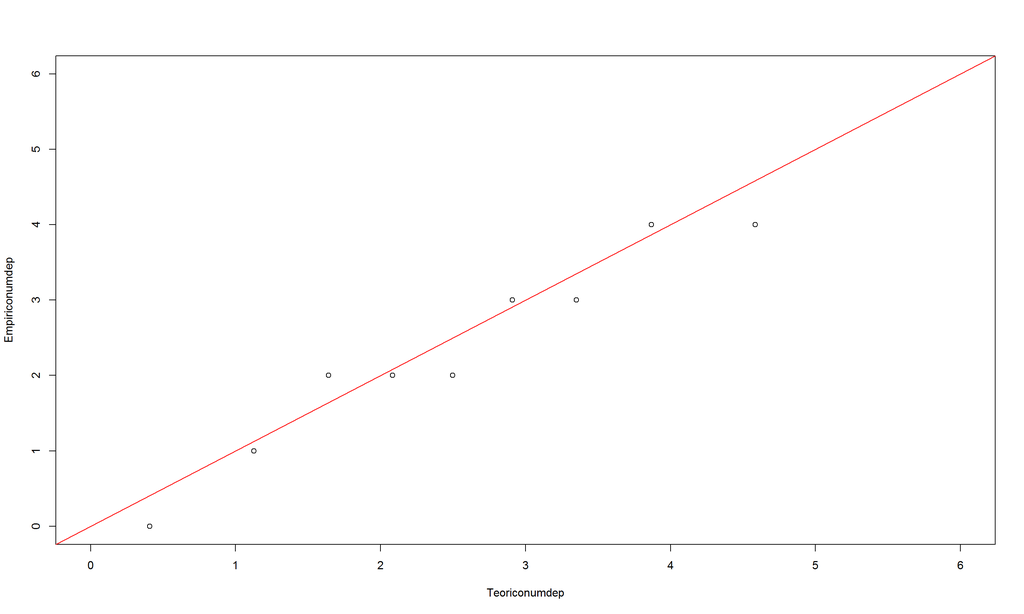

```r
plot(Teoriconumdep, Empiriconumdep, ylim=c(0,6), xlim=c(0,6))
abline(0,1, col="red")
```

### Test de normalidad

```r
shapiro.test(na.omit(base3$Número_de_dependientes))
```

```
##
##  Shapiro-Wilk normality test
##
## data:  na.omit(base3$Número_de_dependientes)
## W = 0.93354, p-value < 2.2e-16
```

```r
ks.test(na.omit(base3$Número_de_dependientes), "pnorm", mean = mean(na.omit(base3$Número_de_dependientes)), sd = sd(na.omit(base3$Número_de_dependientes)))
```

```
##
##  Asymptotic one-sample Kolmogorov-Smirnov test
##
## data:  na.omit(base3$Número_de_dependientes)
## D = 0.14236, p-value < 2.2e-16
## alternative hypothesis: two-sided
```

Se aplica el test de shapiro para evaluar normalidad obteniendo así un p value menor a 0.05, rechazando la hipotesis nula que por defecto asumía normalidad en la variable número de dependientes. Por lo tanto se acepta la hipotesis alterna la cual indica que **los datos de la variable número de dependientes no sigue un comportamiento normal**, así mismo se puede observar esta conclusión en los graficos de comparación de deciles e histograma.

### 2.8.2 Prueba de hipótesis

```r
t.test(na.omit(base3$Número_de_dependientes) , alternative="two.sided",
       conf.level=0.95, mu=2)
```

```
##
##  One Sample t-test
##
## data:  na.omit(base3$Número_de_dependientes)
## t = 14.337, df = 2212, p-value < 2.2e-16
## alternative hypothesis: true mean is not equal to 2
## 95 percent confidence interval:
##  2.428684 2.564538
## sample estimates:
## mean of x
##  2.496611
```